# Introduction

## replace those redundant brands

```python
# brand names to change.

brand_map = {'a2 by aerosoles':'aerosoles', "what's what by aerosoles":'aerosoles',
'adidas outdoor':'adidas',
'adriana new york':'adriana',
'alexander mcqueen by puma':'puma', 'alexander mcqueen':'puma',
'alpine':'alpine swiss',
'anne klein ak':'anne klein', 'anne klein sport':'anne klein',
'annie shoes':'annie',
'athena':'athena alexander',
'babe.':'babe',
'baretraps':'bare traps',
'bcbg max azria':'bcbg', 'bcbg paris':'bcbg', 'bcbgeneration':'bcbg',
'beacon shoes':'beacon',
'bebe sport':'bebe', 'bebe stu':'bebe',
'belle by sigerson morrison':'belle', 'belle sigerson morrison':'belle',
'bernie mev':'bernie', 'bernie mev.':'bernie',
'bettye by bettye muller':'bettye muller', 'bettye by bettye muller ':'bettye muller',
"breckelle's":'breckelles',
'callaway footwear':'callaway',
'calvin klein ck':'calvin klein', 'calvin klein jeans':'calvin klein',
'carlos by carlos santana':'carlos santana',
'charles by charles david':'charels david',
'see by chloe':'chloe',
'clarks artisan':'clarks', 'clarks artisan collection':'clarks', 'clarks collection':'clarks',
'cobb hill by new balance':'new balance', 'cobb hill':'new balance',
'maria sharapova by cole haan': 'cole hann',
"corky's":'corkys', "corky's footwear":'corkys', "corkys footwear, inc.":'corkys',
'dearforms':'dearfoams', 'df by dearfoams':'dearfoams',
'derek lam 10 crosby':'derek lam',
'diba.true':'dibatrue',
'dolce&gabbana':'dolce and gabbana', 'dolce & gabbana':'dolce and gabbana', 'dolce by mojo moxy':'dolce and gabbana',
  'dolce vita':'dolce and gabbana', 'dv8 by dolce vita':'dolce and gabbana', 'dv by dolce vita':'dolce and gabbana',
"dr. scholl's":'dr scholls',
"dr. martens air wair":'drmartens',
'drew shoe':'drew',
'easy spirit e360':'easy spirit', 'easy spirit.':'easy spirit',
'ellie shoes':'ellie',
'emu australia':'emu',
'fergie footwear':'fergie',
'forever collectible':'forever', 'forever link':'forever', 'fourever funky':'forever',
'sarto by franco sarto':'franco sarto',
'ferriniusa':'ferrini',
'fitflop':'fit flop',
'funtasma by pleaser':'funtasma',
'g by guess':'guess',
'gc shoes':'gc',
'genuine grip footwear':'genuine grip',
"hogan by tod's":'hogan',
'soft style by hush puppies':'hush puppies',
'ilse jacobsen hornbaek':'ilse jacobson',
'isaacmizrahi':'isaac mizrahi',
'italian shoe makers':'italian comfort',
'j.renee':'j. renee',
'jbu by jambu':'jambu',
'josefseibel':'josef siebel',
'justin blair':'justin', 'justin boots':'justin', 'justin gypsy':'justin',
'kate spade new york':'kate spade',
'kenneth cole reaction':'kenneth cole', 'kenneth cole ny':'kenneth cole', 'kenneth cole new york':'kenneth cole',
 'unlisted kenneth cole':'kenneth cole',
'lamo sheepskin inc':'lamo',
'lifestride':'lifes tride',
'luoluo':'luo luo',
'marc fisher ltd':'marc fisher',
'mia heritage':'mia',
'micahel kors':'michael kors', 'michael michael kors':'michael kors',
'mobils by mephisto':'mephisto',
'top moda':'moda', 'moda essentials':'moda', 'everybody by bz moda':'moda',
'muk luks a la mode':'muk luks',
'munro american':'munro',
'naot footwear':'naot',
'new@titude':'new attitude', 'new@ttitude':'new attitude',
'nina originals':'nina',
'nine west vintage america collection':'nine west',
'nufoot':'nufoot',
'pleaser shoes':'pleaser', 'pleaser usa, inc.':'pleaser', 'pleaserusa':'pleaser',
'rachel':'rachel roy', 'rachel rachel roy ':'rachel roy',
'lauren by ralph lauren':'ralph lauren', 'lauren ralph lauren':'ralph lauren', 'lauren lorraine':'ralph lauren',
 'polo ralph lauren':'ralph lauren','ralph lauren denim supply':'ralph lauren',
'rieker-antistress':'rieker',
'rocket dog brands llc':'rocket dog',
'sanita clogs':'sanita',
'ferragamo':'salvatore ferragamo',
'skechers usa':'skechers',
'sperry top sider':'sperry', 'sperry top-sider':'sperry',
"l'artiste by spring step":'spring step', "flexus by spring step":'spring step', "patrizia by spring step ":'spring step',
 "patrizia pepe":'spring step', "patrizia":'spring step',
'steven steve madden':'steve madden',
'style & co.':'style and co',
'timberland earthkeepers':'timberland', 'timberland pro':'timberland',
'toms shoes':'toms',
'tony lama boot co.':'tony lama',
'totes isotoner':'totes',
'trotter':'trotters',
'ugg australia':'ugg',
'famous name brand':'unbranded', 'generic':'unbranded', 'generic surplus':'unbranded', 'non-branded':'unbranded',
 'not applicable':'unbranded', 'not rated':'unbranded', 'lucky  brand':'unbranded', 'lucky brand':'unbranded',
 'very fine dance shoes':'unbranded',
'valentino noir':'valentino',
'victoria k.':'victoria',
'vince camuto':'vince',
'vionic by orthaheel':'vionic', 'vionic with orthaheel technology':'vionic',
'elites by walking cradles':'walking cradles', 'elites':'walking cradles','mark lemp by walking cradles':'walking cradles',
 'rose petals by walking cradles':'walking cradles', 'the walking cradle company':'walking cradles'
}
```

```python
data['brand_clean'] = data.brand.replace(brand_map)
```

```python
_= data.groupby('brand')['prices.amountMax'].mean()
_.head(25)
```

```
brand
1 world sarongs         19.763913
143 girl                15.243750
2 lips too              46.950000
361                     80.000000
79 scii                 14.990000
90 degree by reflex     12.500000
Unbranded              107.761098
a'rcopedico             58.995000
a.n.a                   39.437778
a.x.n.y.                41.901818
a2 by aerosoles         54.917959
abound                   7.990000
acacia                  24.990000
academie gear           58.027174
acorn                   54.038393
adam tucker             49.294444
adi                     32.658095
adidas                  85.581684
adidas outdoor          85.490000
adieu                  565.000000
adriana                 36.323333
adriana new york        16.991667
adrienne vittadini      54.851429
adtec                   75.190270
aeropostale             31.282500
Name: prices.amountMax, dtype: float64
```

## Now let's convert all those non dollar transactions

```python
data['prices.currency'].value_counts()
```

```
USD    32588
CAD     1008
EUR      101
AUD       11
GBP        1
Name: prices.currency, dtype: int64
```

we have to convert all those canadian dollars australian dollars euros & sterlings to USD or domestic currency

```python
data.shape
```

```
(33709, 30)
```

```python
from currency_converter import CurrencyConverter
EUR = CurrencyConverter().convert(1, currency= 'EUR', new_currency= 'USD');  # this Currencyconverter() eats cpu s
CAD = CurrencyConverter().convert(1, currency= 'CAD', new_currency= 'USD'); #so it is wise to fetch the conversion once
AUD = CurrencyConverter().convert(1, currency= 'AUD', new_currency= 'USD');
GBP = CurrencyConverter().convert(1, currency= 'GBP', new_currency= 'USD');
f"{EUR},{CAD},{AUD},{GBP}"
```

```
'1.1209,0.7434009815625414,0.7039944730561486,1.2951643653590617'
```

```python
data['prices.amountMin_converted'] = data['prices.amountMin'].copy()
data['prices.amountMax_converted'] = data['prices.amountMax'].copy()


data.loc[data['prices.currency']=='EUR', 'prices.amountMin_converted'] = data['prices.amountMin']*EUR
data.loc[data['prices.currency']=='EUR', 'prices.amountMax_converted'] = data['prices.amountMax']*EUR
data.loc[data['prices.currency']=='CAD', 'prices.amountMin_converted'] = data['prices.amountMin']*CAD
data.loc[data['prices.currency']=='CAD', 'prices.amountMax_converted'] = data['prices.amountMax']*CAD
data.loc[data['prices.currency']=='AUD', 'prices.amountMin_converted'] = data['prices.amountMin']*AUD
data.loc[data['prices.currency']=='AUD', 'prices.amountMax_converted'] = data['prices.amountMax']*AUD
data.loc[data['prices.currency']=='GBP', 'prices.amountMin_converted'] = data['prices.amountMin']*GBP
data.loc[data['prices.currency']=='GBP', 'prices.amountMax_converted'] = data['prices.amountMax']*GBP
```

## we save our intermediate file

```python
# before we do further analysis we copy our present data to a version file

data_version3 = data.copy() # data_version2 = data minus empty columns

# lets drop some columns which are not useful for analysis we are going to do next
# but it is always advised to not drop anything but only pick those needed
data.drop(['weight', 'prices.returnPolicy', 'prices.shipping', 'manufacturer', 'prices.offer', 'prices.condition', 'gender', 'merchants', 'prices.merchant', 'prices.size', 'prices.color', 'features','descriptions', 'colors'], axis=1, inplace=True)
```

## visualize NaN again

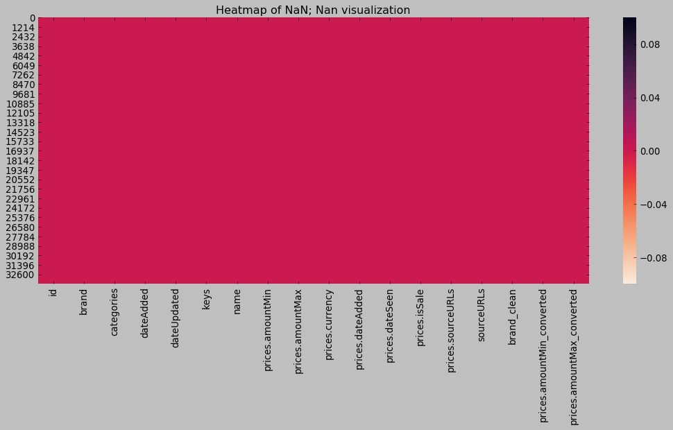

```python
fig, ax = plt.subplots(figsize=(16,6))
naheatmap(data)
```

## so we have a clean data!!

# Which brands have the highest prices?

```python
data.groupby('brand')['prices.amountMax_converted'].mean().sort_values(ascending= False).head(20)
```

```
brand
jewelsobsession        3322.190000
teva                   1512.699640
valentino              1186.998000
simone rocha           1120.000000
malone souliers        1100.000000
nicholas kirkwood      1095.000000
marni                   963.333333
paul andrew             895.000000
stella mccartney        885.000000
christian louboutin     867.333333
giuseppe zanotti        851.666667
givenchy                850.000000
saint laurent           828.333333
jimmy choo              789.375000
gucci                   752.999091
ivy kirzhner            750.000000
charlotte olympia       745.000000
alexander wang          743.300000
ralph lauren            702.179143
prada                   693.772222
Name: prices.amountMax_converted, dtype: float64
```

```python
# for most expensive brands we take mean in the 4 th quantile
# for the least expensive brands we take mean in the 1st quantile

def top40(data):
    Top40 = list(data.groupby('brand')['prices.amountMax_converted'].mean().sort_values(ascending= False).head(40).index)
    fig, ax = plt.subplots(figsize=(16,6))
    sns.stripplot(data = data[data.brand.isin(Top40)], x='brand', y='prices.amountMax_converted');
    plt.xticks(rotation=90);

def bottom40(data):
    bottom40 = list(data.groupby('brand')['prices.amountMin_converted'].mean().sort_values(ascending= True).head(40).index)
    fig, ax = plt.subplots(figsize=(16,6))
    sns.stripplot(data = data[data.brand.isin(bottom40)], x='brand', y='prices.amountMin_converted');
    plt.xticks(rotation=90);
```

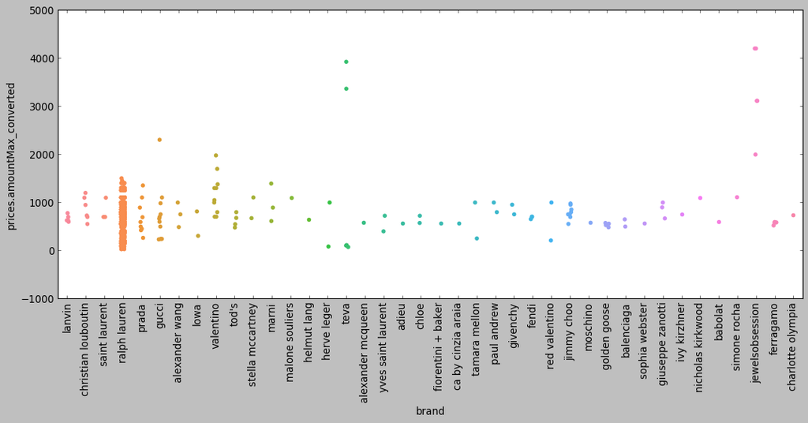

```python
top40(data)
```

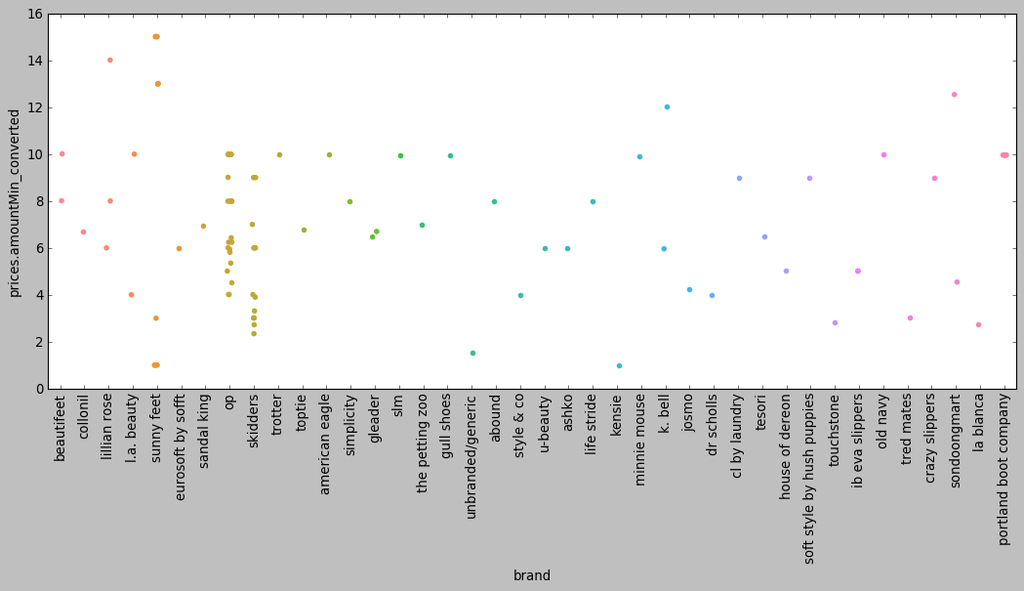

```python
bottom40(data)
```

```python
data[data.brand=='jewelsobsession']
```

|  | id | brand | categories | dateAdded | dateUpdated | keys | name | prices.amountMin | prices.amountMax | prices.currency | prices.dateAdded | prices.dateSeen | prices.isSale | prices.sourceURLs | sourceURLs | brand_clean | prices.amountMin_converted | prices.amountMax_converted |
| --- | --- | --- | --- | --- | --- | --- | --- | --- | --- | --- | --- | --- | --- | --- | --- | --- | --- | --- |
| 21219 | AVphQOzn1cnluZ0-AQNk | jewelsobsession | Fine,Women,Clothing, Shoes & Jewelry,Jewelry | 2015-09-01T18:31:27Z | 2016-09-24T03:51:47Z | jewelsobsession/az65461100800p126,diamondetern... | Diamond Eternity Band | 4198.99 | 4198.99 | USD | 2015-12-11T01:52:22Z | 2016-02-28T00:00:00Z | False | http://www.amazon.com/JewelsObsession-AZ65461-... | https://www.amazon.com/JewelsObsession-AZ65461... | jewelsobsession | 4198.99 | 4198.99 |
| 21220 | AVphQOzn1cnluZ0-AQNk | jewelsobsession | Fine,Women,Clothing, Shoes & Jewelry,Jewelry | 2015-09-01T18:31:27Z | 2016-09-24T03:51:47Z | jewelsobsession/az65461100800p126,diamondetern... | Diamond Eternity Band | 4198.99 | 4198.99 | USD | 2015-12-11T01:52:22Z | 2016-03-20T00:00:00Z | False | http://www.amazon.com/JewelsObsession-AZ65461-... | https://www.amazon.com/JewelsObsession-AZ65461... | jewelsobsession | 4198.99 | 4198.99 |
| 21221 | AVphQOzn1cnluZ0-AQNk | jewelsobsession | Fine,Women,Clothing, Shoes & Jewelry,Jewelry | 2015-09-01T18:31:27Z | 2016-09-24T03:51:47Z | jewelsobsession/az65461100800p126,diamondetern... | Diamond Eternity Band | 3109.99 | 3109.99 | USD | 2015-12-11T01:52:22Z | 2016-02-28T00:00:00Z | True | http://www.amazon.com/JewelsObsession-AZ65461-... | https://www.amazon.com/JewelsObsession-AZ65461... | jewelsobsession | 3109.99 | 3109.99 |
| 21222 | AVphQOzn1cnluZ0-AQNk | jewelsobsession | Fine,Women,Clothing, Shoes & Jewelry,Jewelry | 2015-09-01T18:31:27Z | 2016-09-24T03:51:47Z | jewelsobsession/az65461100800p126,diamondetern... | Diamond Eternity Band | 3109.99 | 3109.99 | USD | 2015-12-11T01:52:22Z | 2016-03-20T00:00:00Z | True | http://www.amazon.com/JewelsObsession-AZ65461-... | https://www.amazon.com/JewelsObsession-AZ65461... | jewelsobsession | 3109.99 | 3109.99 |
| 21223 | AVphQOzn1cnluZ0-AQNk | jewelsobsession | Fine,Women,Clothing, Shoes & Jewelry,Jewelry | 2015-09-01T18:31:27Z | 2016-09-24T03:51:47Z | jewelsobsession/az65461100800p126,diamondetern... | Diamond Eternity Band | 1992.99 | 1992.99 | USD | 2015-12-11T01:52:22Z | 2016-02-28T00:00:00Z | True | http://www.amazon.com/JewelsObsession-AZ65461-... | https://www.amazon.com/JewelsObsession-AZ65461... | jewelsobsession | 1992.99 | 1992.99 |

```python
checklist = data[data.brand=='jewelsobsession'].id.iloc[:5].tolist()
```

```python
data_version1[data_version1.id.isin(checklist)]['imageURLs']
```

```
21219    http://ecx.images-amazon.com/images/I/31Ndh8nw...
21220    http://ecx.images-amazon.com/images/I/31Ndh8nw...
21221    http://ecx.images-amazon.com/images/I/31Ndh8nw...
21222    http://ecx.images-amazon.com/images/I/31Ndh8nw...
21223    http://ecx.images-amazon.com/images/I/31Ndh8nw...
Name: imageURLs, dtype: object
```

```python
# lets look at the urls to see what kind of shoe is this expensive !!
from IPython.display import IFrame
for i,j in enumerate (data_version1[data_version1.id.isin(checklist)]['imageURLs']):
    IFrame(src=j, width=40, height=40)
```

[interactive chart not shown]

after some digging we see that jewelsobsseion is not a sandals company # well i actually just googled it

let's drop jewelsobsession

```python
data.drop(data[data.brand=='jewelsobsession'].index, axis=0, inplace=True)
```

lets see distribution

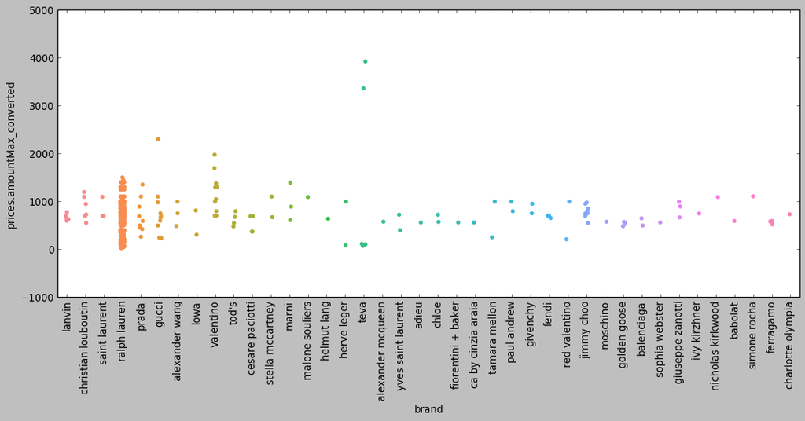

```python
top40(data)
```

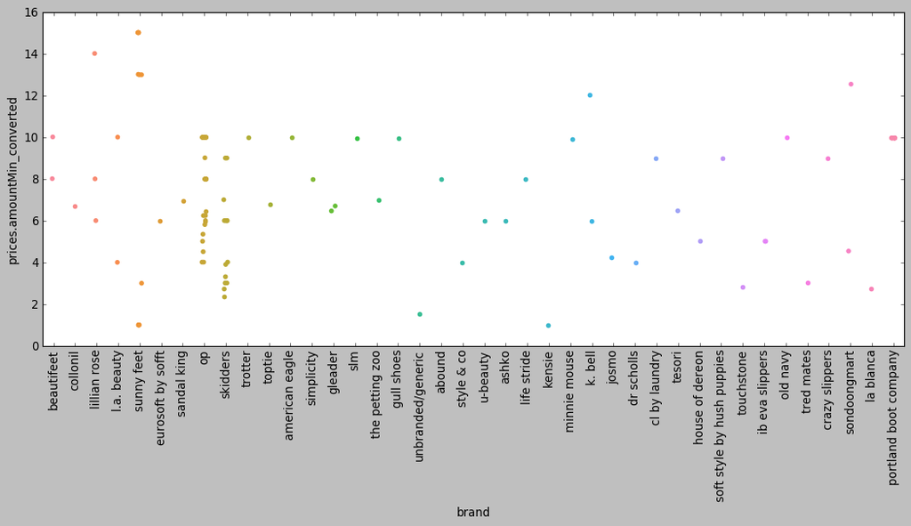

```python
bottom40(data)
```

## Ralph lauren seems to be one of the most expensive and most traded brand

# What is the average price of each distinct brand listed?

```python
_=data.groupby('brand')['prices.amountMin_converted'].mean().sample(20) # 20 samples
_
```

```
brand
toptie                            6.750081
ralph lauren denim supply        92.495000
silvert's                        56.068182
woolrich                         72.820000
harley-davidson                  57.370000
babe.                            42.323333
generic                          14.671818
restricted                       31.266364
luxury divas                     25.400000
miz mooz                        102.607500
ugg                             160.525760
new@ttitude                      25.742500
luo luo                          19.911667
naughty monkey                   50.340000
fiorentini + baker              565.950000
betty boop signature product     15.890000
grasshoppers                     35.740347
willowbee                        41.995000
life is good                     37.950000
dbdk fashion                     34.772222
Name: prices.amountMin_converted, dtype: float64
```

```python
data.describe()
```

|  | prices.amountMin | prices.amountMax | prices.amountMin_converted | prices.amountMax_converted |
| --- | --- | --- | --- | --- |
| count | 33704.000000 | 33704.000000 | 33704.000000 | 33704.000000 |
| mean | 87.292698 | 88.583454 | 86.592161 | 87.933118 |
| std | 140.586849 | 146.231590 | 140.944658 | 147.985133 |
| min | 0.010000 | 0.010000 | 0.010000 | 0.010000 |
| 25% | 33.990000 | 34.390000 | 33.990000 | 34.360000 |
| 50% | 52.990000 | 53.690000 | 51.990000 | 53.000000 |
| 75% | 89.000000 | 89.950000 | 87.960000 | 89.000000 |
| max | 4270.000000 | 5200.000000 | 4786.243000 | 5828.680000 |

# Which ones have the widest distribution of prices?

```python
(data.groupby('brand')['prices.amountMax_converted'].max() - data.groupby('brand')['prices.amountMin_converted'].min()).sort_values(ascending=False).head(10)
```

```
brand
Unbranded            5826.539005
teva                 3892.029100
gucci                2071.000000
ralph lauren         1475.010000
valentino            1275.010000
prada                1090.050000
burberry             1015.050000
herve leger           915.010000
vivienne westwood     836.010000
red valentino         788.010000
dtype: float64
```

teva, gucci, ralph , valentino, prada ... these companies have widest distribution of prices

# Is there a typical price distribution (e.g., normal) across brands or within specific brands?

```python
import scipy
```

```python
stats.normaltest(data['prices.amountMax_converted']) # p=0 The null hypothesis can be rejected ;so there is no normality in price distribution across all brands
```

```
NormaltestResult(statistic=48197.097642557615, pvalue=0.0)
```

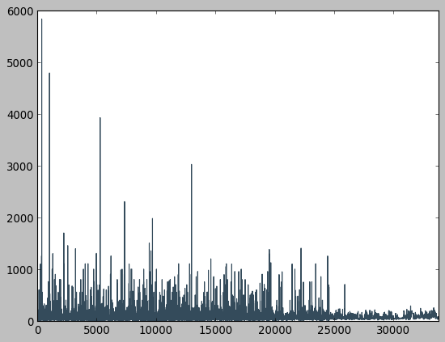

```python
data['prices.amountMax_converted'].plot()
```

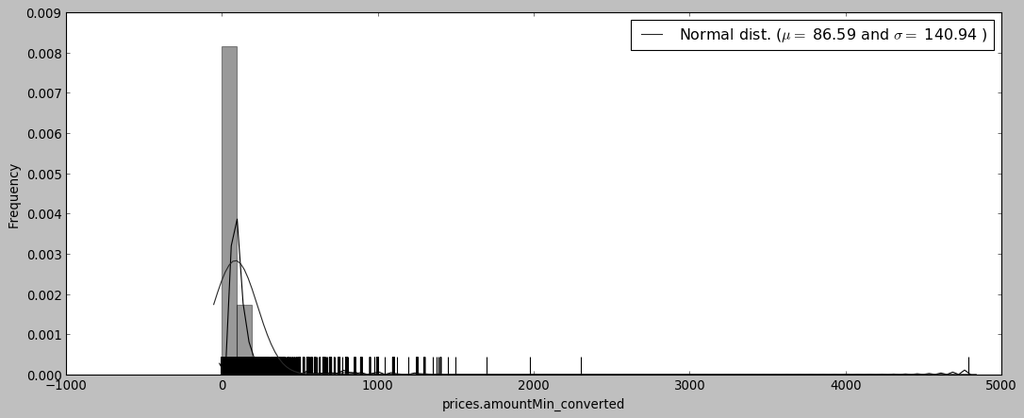

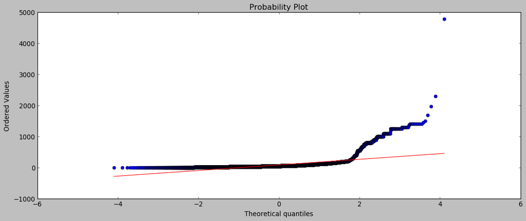

```python
fig, ax = plt.subplots(figsize=(16,6))
sns.distplot(data['prices.amountMin_converted'], fit=stats.norm, color='black', norm_hist=True, ax=ax, rug =True);

# mean and std deviation of the distribution
(mean, std) = stats.norm.fit(data['prices.amountMin_converted'])
plt.ylabel('Frequency')
plt.legend(['Normal dist. ($\mu=$ {:.2f} and $\sigma=$ {:.2f} )'.format(mean, std)], loc='best')



# plot probability plots now :
fig, ax = plt.subplots(figsize=(16,6))
stats.probplot(data['prices.amountMin_converted'], plot=plt);
```

we can see that the distribution is right skewed : https://en.wikipedia.org/wiki/Skew_normal_distribution

Skewness is a measure of symmetry, or more precisely, the lack of symmetry. A distribution, or data set, is symmetric if it looks the same to the left and right of the center point.

Kurtosis is a measure of whether the data are heavy-tailed or light-tailed relative to a normal distribution. That is, data sets with high kurtosis tend to have heavy tails, or outliers. Data sets with low kurtosis tend to have light tails, or lack of outliers.

```python
data['prices.amountMin_converted'].skew() # positive skewness
```

```
6.368441623047426
```

https://www.investopedia.com/terms/l/leptokurtic.asp

Normal distribution has a kurtosis of 3 i.e 3 standard deviations;

Leptokurtic distributions are statistical distributions with occurrences plotted beyond 3 standard deviations. This results in more occurrences farther from the mean and a higher kurtosis. Leptokurtic distributions are known for having more than three standard deviations which is beyond that of a normal distribution. They are also known for having fatter tails because a higher number of occurrences are plotted beyond three standard deviations.

In general, leptokurtic distributions have heavier tails or a higher probability of extreme outlier values when compared to mesokurtic or platykurtic distributions.

While leptokurtosis refers to greater outlier potential, mesokurtosis and platykurtosis describe lesser outlier potential. Mesokurtic distributions have kurtosis near 3.0, meaning that their outlier character is similar to that of the normal distribution. Platykurtic distributions have kurtosis less than 3.0, thus exhibiting less kurtosis than a normal distribution.

```python
data['prices.amountMin_converted'].kurtosis()
```

```
70.53460844989137
```

```python
# we take log1p() since asset prises are non negative : log 0.01 will result in -2 which is not correct way to handle skewness
data['prices.amountMin_converted'] = numpy.log1p(data['prices.amountMin_converted'])
data['prices.amountMax_converted'] = numpy.log1p(data['prices.amountMax_converted'])
```

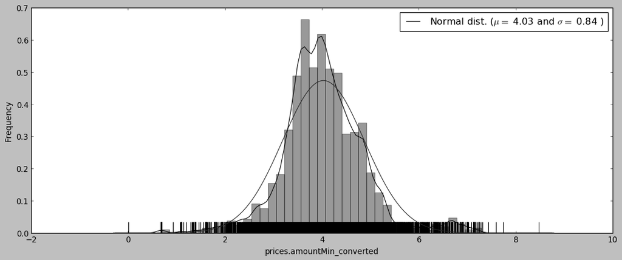

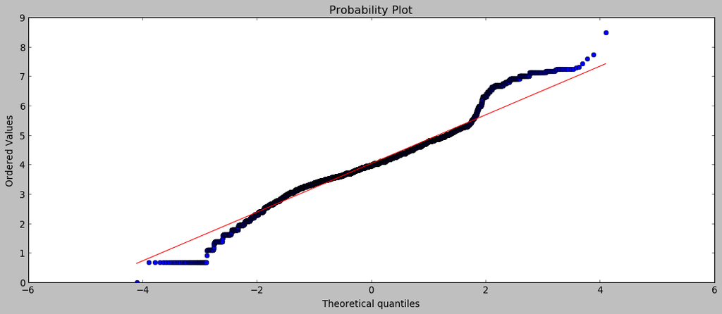

```python
fig, ax = plt.subplots(figsize=(16,6))
sns.distplot(data['prices.amountMin_converted'], fit=stats.norm, color='black', norm_hist=True, ax=ax, rug =True);

# mean and std deviation of the distribution
(mean, std) = stats.norm.fit(data['prices.amountMin_converted'])
plt.ylabel('Frequency')
plt.legend(['Normal dist. ($\mu=$ {:.2f} and $\sigma=$ {:.2f} )'.format(mean, std)], loc='best')



# plot probability plots now :
fig, ax = plt.subplots(figsize=(16,6))
stats.probplot(data['prices.amountMin_converted'], plot=plt);
```

```python
data['prices.amountMin_converted'].kurtosis()
data['prices.amountMin_converted'].skew()
```

```
2.261612365355263
```

```
0.40594528396777335
```

## The prices have no normal distribution across brands .

# References

```
        https://www.kaggle.com/datafiniti/womens-shoes-prices
        https://en.wikipedia.org/wiki/Missing_data
        https://pypi.org/project/CurrencyConverter/
        https://measuringu.com/missing-data/
        https://www.statisticssolutions.com/missing-values-in-data/
        https://www.kaggle.com/ashishg21/data-cleaning-and-some-analysis-shoe-prices
```